[figure not shown]

[figure not shown]

**COMPONENTE CURRICULAR:** Química **DATA**: _____/____/______  
**TURMA:** 3ª Série Ensino Médio **PROFESSOR:** Jailson Duarte  
**ALUNO(A):** ________________________________________________

# Química Orgânica

**02.** A cadeia carbônica abaixo é classificada como:

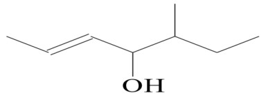

1. Aberta, ramificada, insaturada, heterogênea
2. Alicíclica, ramificada, insaturada, heterogênea
3. Acíclica, ramificada, insaturada, homogênea
4. Alifática, linear, saturada, homogênea
5. Aberta, linear, saturada, heterogênea

**03.** A preocupação com o bem-estar e a saúde é uma das características da sociedade moderna. Um dos recentes lançamentos que evidenciam essa preocupação no setor de alimentos é o leite com ômega-3. Essa substância não é produzida pelo nosso organismo, e estudos revelam que sua ingestão é importante para evitar problemas cardiovasculares. A estrutura química do ômega-3 pode ser assim representada:

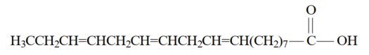

Com relação à estrutura química do ômega-3, é correto afirmar que essa substância possui cadeia carbônica

1. alifática, homogênea, saturada e ramificada.
2. alicíclica, heterogênea, insaturada e ramificada.
3. alifática, homogênea, insaturada e normal.
4. homocíclica, heterogênea, saturada e normal.
5. alicíclica, homogênea, saturada e normal.

**04.** O gás liquefeito de petróleo, GLP, é uma mistura de propano, C3H8, e butano,C4H10. Logo, esse gás é uma mistura de hidrocarbonetos da classe dos:

a)alcanos. b)alcenos. c)alcinos d)cicloalcanos. e)cicloalcenos.

**05.** Considere as afirmações seguintes sobre hidrocarbonetos.

I. Hidrocarbonetos são compostos orgânicos constituídos somente de carbono e hidrogênio.

II.São chamados de alcenos somente os hidrocarbonetos insaturados de cadeia linear.

a)I e III, apenas. b)I, III e IV, apenas. c)II e III, apenas. d)III e IV, apenas. e)I, II e IV, apenas.

**06.** “Química Orgânica é o ramo da Química que estuda os compostos do carbono”. A maioria dos seus compostos são importantes em nossas vidas, destacando o álcool comum, a gasolina, o ácido acético, as proteínas e as vitaminas.

Assinale a alternativa que mostra a característica correta do átomo de carbono.

1. Forma ligação tripla, e nesta situação o carbono é do tipo sp3.
2. O carbono é tetravalente somente nos hidrocarbonetos.
3. Apresenta capacidade de formar cadeias longas, variadas e estáveis.
4. Liga-se a várias classes de elementos químicos, com exceção da classe dos calcogênios.

**07.** Uma cadeia carbônica alifática, homogênea, saturada, apresenta um átomo de carbono secundário, dois átomos de carbono quaternário e um átomo de carbono terciário. Esta cadeia apresenta:

a)7 átomos de C. b) 8 átomos de C. c) 9 átomos de C.

d)10 átomos de C. e) 11 átomos de C.

**08.** Componente do óleo da flor de laranjeira, o linalol, tem cadeia carbônica:

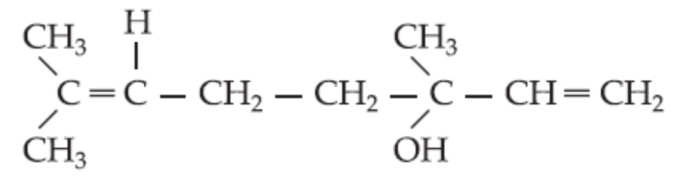

1. cíclica, homogênea e saturada.
2. aberta, insaturada e heterogênea.
3. cíclica, insaturada e aromática.
4. aberta, ramificada e insaturada.
5. cíclica, heterogênea e saturada.

[figure not shown]

1. acíclica, heterogênea, saturada, ramificada
2. mista, heterogênea, insaturada, aromática
3. mista, homogênea, saturada, alicíclica
4. aberta, heterogênea, saturada, aromática
5. mista, homogênea, insaturada, aromática